# Grammar of Graphics

Wed Sep 21, 2016

## What is a statistical graphic?

Today we kick off Topic 2.b) **Data Visualization** by asking ourselves

What is a statistical graphic?

But a brief lesson from military history first:

## Napoleon's March on Russia in 1812

In 1812, Napoleon led a French invasion of Russia, marching on [Moscow](https://goo.gl/maps/geRyXH3rJcK2).

[figure not shown]

## Napoleon's March on Russia in 1812

It was one of the biggest [military disasters](http://www.history.com/news/napoleons-disastrous-invasion-of-russia-200-years-ago) ever, in particular b/c of the Russian winter.

[figure not shown]

## Minard's Illustration of the March

Famous graphical illustration of Napolean's march to/from Moscow

[figure not shown]

## Minard's Illustration of the March

This was considered a revolution in statistical graphics because between

- the map on top
- the line graph on the bottom

there are 6 dimensions of information (i.e. variables) being displayed on a 2D page.

## The Grammar of Graphics

A statistical graphic is a mapping of `data` variables to `aes()`thetic attributes of `geom_`etric objects.

## Minard's Illustration of the March

| Where? | **`data`** | **`aes()`** | **`geom_`** |
| --- | --- | --- | --- |
| top map | longitude | **`x`** | **`point`** |
| " | latitude | **`y`** | **`point`** |
| " | army size | **`size`** | **`path`** |
| " | army direction (forward vs retreat) | **`color`** | **`path`** |
| bottom graph | date | **`x`** | **`line`** & **`text`** |
| " | temperature | **`y`** | **`line`** & **`text`** |

## Grammar of Graphics

Wilkinson (2005) laid out the proposed "Grammar of Graphics"

[figure not shown]

## Grammar of Graphics

Wickham implemented the grammar in R in `ggplot2` package

[figure not shown]

## Edward Tufte

Another seminal book is Tufte's "The Visual Display of Quantitative Information"

[figure not shown]

## Types of Graphs

Name this graph type!

## Types of Graphs

From `ggplot2movies` package, the `movies` data set:

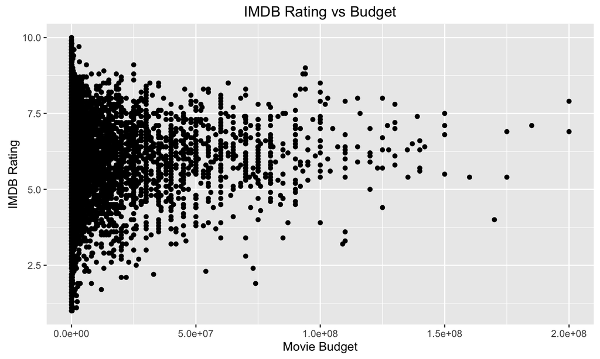

## Types of Graphs

From `nycflights13` package, the `flights` data set:

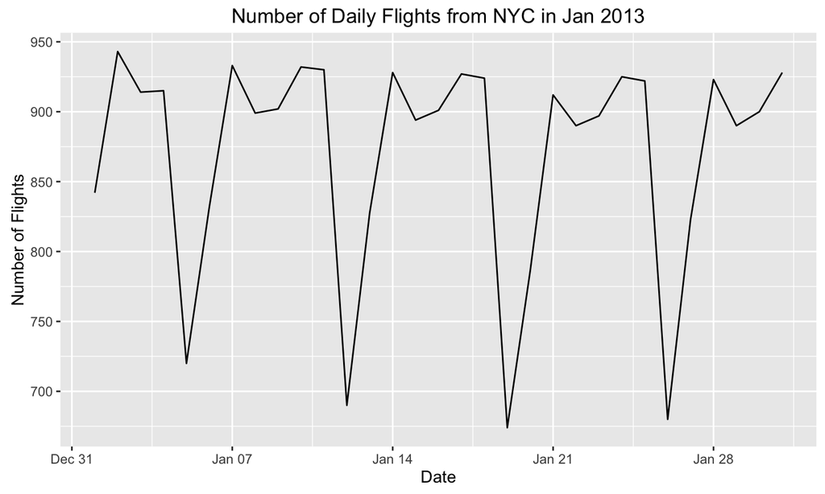

## Types of Graphs

From `fueleconomy` package, the `vehicles` data set:

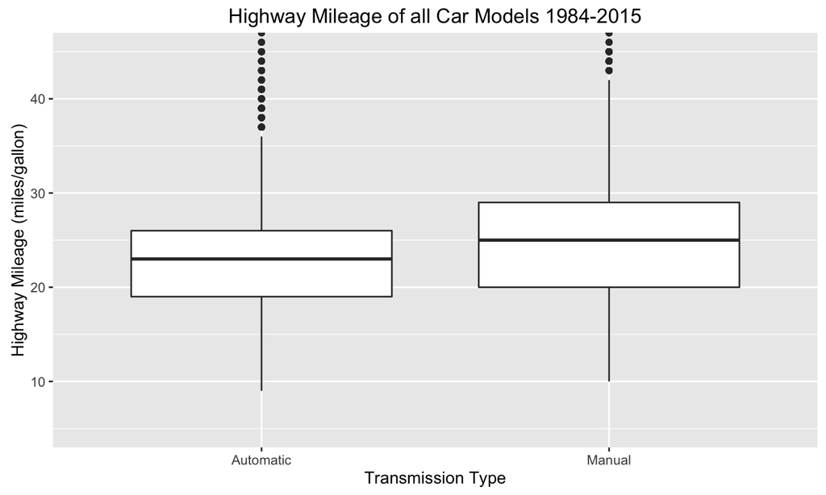

## Types of Graphs

From `babynames` package, the `babynames` data set:

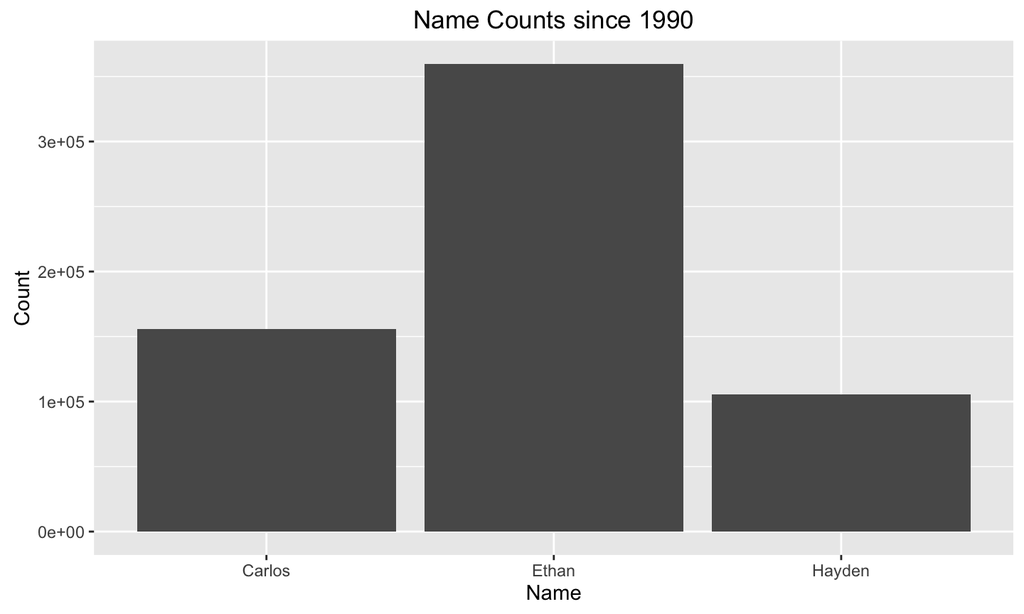

## Types of Graphs

From `okcupiddata` package, the `profiles` data set:

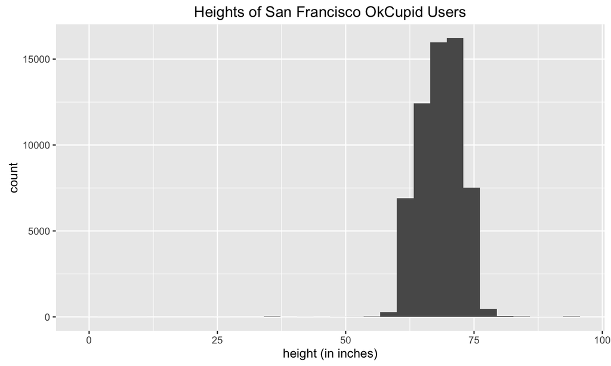

## 5NG

Say hello to the 5NG: the **five named graphs**

1. Scatterplot AKA bivariate plot
2. Line-graph
3. Boxplot
4. Barplot AKA Barchart AKA bargraph
5. Histogram